# Part I - Communicate Data Findings Project

## Introduction

### Dataset : Ford Gobike System Data

> This dataset includes information about individual rides made in a bike-sharing system covering the greater San Francisco Bay area in the year 2018.

## Preliminary Wrangling

```python
# import all packages and set plots to be embedded inline
import pandas as pd
import numpy as np
import seaborn as sb
import matplotlib.pyplot as plt
%matplotlib inline
```

## Gathering

```python
# load datasets and append

df1  = pd.read_csv('201801-fordgobike-tripdata.csv')
df2  = pd.read_csv('201802-fordgobike-tripdata.csv')
df3  = pd.read_csv('201803-fordgobike-tripdata.csv')
df4  = pd.read_csv('201804-fordgobike-tripdata.csv')
df5  = pd.read_csv('201805-fordgobike-tripdata.csv')
df6  = pd.read_csv('201806-fordgobike-tripdata.csv')
df7  = pd.read_csv('201807-fordgobike-tripdata.csv')
df8  = pd.read_csv('201808-fordgobike-tripdata.csv')
df9  = pd.read_csv('201809-fordgobike-tripdata.csv')
df10 = pd.read_csv('201810-fordgobike-tripdata.csv')
df11 = pd.read_csv('201811-fordgobike-tripdata.csv')
df12 = pd.read_csv('201812-fordgobike-tripdata.csv')
```

```python
df = df1.append([df2,df3,df4,df5,df6,df7,df8,df9,df10,df11,df12])
bike = df.copy()
```

```python
bike.head()
```

|  | duration_sec | start_time | end_time | start_station_id | start_station_name | start_station_latitude | start_station_longitude | end_station_id | end_station_name | end_station_latitude | end_station_longitude | bike_id | user_type | member_birth_year | member_gender | bike_share_for_all_trip |
| --- | --- | --- | --- | --- | --- | --- | --- | --- | --- | --- | --- | --- | --- | --- | --- | --- |
| 0 | 75284 | 2018-01-31 22:52:35.2390 | 2018-02-01 19:47:19.8240 | 120.0 | Mission Dolores Park | 37.761420 | -122.426435 | 285.0 | Webster St at O'Farrell St | 37.783521 | -122.431158 | 2765 | Subscriber | 1986.0 | Male | No |
| 1 | 85422 | 2018-01-31 16:13:34.3510 | 2018-02-01 15:57:17.3100 | 15.0 | San Francisco Ferry Building (Harry Bridges Pl... | 37.795392 | -122.394203 | 15.0 | San Francisco Ferry Building (Harry Bridges Pl... | 37.795392 | -122.394203 | 2815 | Customer | NaN | NaN | No |
| 2 | 71576 | 2018-01-31 14:23:55.8890 | 2018-02-01 10:16:52.1160 | 304.0 | Jackson St at 5th St | 37.348759 | -121.894798 | 296.0 | 5th St at Virginia St | 37.325998 | -121.877120 | 3039 | Customer | 1996.0 | Male | No |
| 3 | 61076 | 2018-01-31 14:53:23.5620 | 2018-02-01 07:51:20.5000 | 75.0 | Market St at Franklin St | 37.773793 | -122.421239 | 47.0 | 4th St at Harrison St | 37.780955 | -122.399749 | 321 | Customer | NaN | NaN | No |
| 4 | 39966 | 2018-01-31 19:52:24.6670 | 2018-02-01 06:58:31.0530 | 74.0 | Laguna St at Hayes St | 37.776435 | -122.426244 | 19.0 | Post St at Kearny St | 37.788975 | -122.403452 | 617 | Subscriber | 1991.0 | Male | No |

```python
bike.shape
```

```
(1863721, 16)
```

```python
bike.info()
```

```
<class 'pandas.core.frame.DataFrame'>
Int64Index: 1863721 entries, 0 to 131362
Data columns (total 16 columns):
 #   Column                   Dtype
---  ------                   -----
 0   duration_sec             int64
 1   start_time               object
 2   end_time                 object
 3   start_station_id         float64
 4   start_station_name       object
 5   start_station_latitude   float64
 6   start_station_longitude  float64
 7   end_station_id           float64
 8   end_station_name         object
 9   end_station_latitude     float64
 10  end_station_longitude    float64
 11  bike_id                  int64
 12  user_type                object
 13  member_birth_year        float64
 14  member_gender            object
 15  bike_share_for_all_trip  object
dtypes: float64(7), int64(2), object(7)
memory usage: 241.7+ MB
```

```python
# check for duplicates
sum(bike.duplicated())
```

```
0
```

## Data Cleaning

```python
# clean start_time and end_time columns and convert to datetime format

bike['start_time'] =bike['start_time'].str[:19]
bike['end_time'] =bike['end_time'].str[:19]

bike['start_time'] = pd.to_datetime(bike['start_time'])
bike['end_time'] = pd.to_datetime(bike['end_time'])
```

```python
bike.info()
```

```
<class 'pandas.core.frame.DataFrame'>
Int64Index: 1863721 entries, 0 to 131362
Data columns (total 16 columns):
 #   Column                   Dtype
---  ------                   -----
 0   duration_sec             int64
 1   start_time               datetime64[ns]
 2   end_time                 datetime64[ns]
 3   start_station_id         float64
 4   start_station_name       object
 5   start_station_latitude   float64
 6   start_station_longitude  float64
 7   end_station_id           float64
 8   end_station_name         object
 9   end_station_latitude     float64
 10  end_station_longitude    float64
 11  bike_id                  int64
 12  user_type                object
 13  member_birth_year        float64
 14  member_gender            object
 15  bike_share_for_all_trip  object
dtypes: datetime64[ns](2), float64(7), int64(2), object(5)
memory usage: 241.7+ MB
```

```python
# correct values in duration_sec column
bike['duration_sec'] =  (bike['end_time'] - bike['start_time']).dt.total_seconds().astype(int)

# drop wrong durations due to wrong start and end times.
ind = bike[bike['duration_sec']<0].index
bike.drop(np.r_[ind] , inplace = True)
bike.head(3)
```

|  | duration_sec | start_time | end_time | start_station_id | start_station_name | start_station_latitude | start_station_longitude | end_station_id | end_station_name | end_station_latitude | end_station_longitude | bike_id | user_type | member_birth_year | member_gender | bike_share_for_all_trip |
| --- | --- | --- | --- | --- | --- | --- | --- | --- | --- | --- | --- | --- | --- | --- | --- | --- |
| 0 | 75284 | 2018-01-31 22:52:35 | 2018-02-01 19:47:19 | 120.0 | Mission Dolores Park | 37.761420 | -122.426435 | 285.0 | Webster St at O'Farrell St | 37.783521 | -122.431158 | 2765 | Subscriber | 1986.0 | Male | No |
| 1 | 85423 | 2018-01-31 16:13:34 | 2018-02-01 15:57:17 | 15.0 | San Francisco Ferry Building (Harry Bridges Pl... | 37.795392 | -122.394203 | 15.0 | San Francisco Ferry Building (Harry Bridges Pl... | 37.795392 | -122.394203 | 2815 | Customer | NaN | NaN | No |
| 2 | 71577 | 2018-01-31 14:23:55 | 2018-02-01 10:16:52 | 304.0 | Jackson St at 5th St | 37.348759 | -121.894798 | 296.0 | 5th St at Virginia St | 37.325998 | -121.877120 | 3039 | Customer | 1996.0 | Male | No |

```python
# get distance in kilometers via longitude and latitude

def haversine(lat1, lon1, lat2, lon2, to_radians=True, earth_radius=6371):
    if to_radians:
        lat1, lon1, lat2, lon2 = np.radians([lat1, lon1, lat2, lon2])

    a = np.sin((lat2-lat1)/2.0)**2 + \
        np.cos(lat1) * np.cos(lat2) * np.sin((lon2-lon1)/2.0)**2

    return earth_radius * 2 * np.arcsin(np.sqrt(a))


bike['dist'] = haversine(bike['start_station_latitude'], bike['start_station_longitude'],bike['end_station_latitude']
                       , bike['end_station_longitude'])
```

```python
# remove zero distance trips
bike = bike[bike['dist'] > 0]
```

```python
# get approximate speed of riders in km/hr
bike['speed'] = (bike['dist'])/ (bike['duration_sec']/3600)
```

```python
# add days of week and month

days = {
    0:'Monday',
    1:'Tuesday',
    2:'Wednesday',
    3:'Thursday',
    4:'Friday',
    5:'Saturday',
    6:'Sunday'
}

months = {

    1: 'January',
    2: 'February',
    3: 'March',
    4: 'April',
    5:'May',
    6:'June',
    7:'July',
    8:'August',
    9:'September',
    10:'October',
    11:'November',
    12:'December'
}

bike['start_day_of_week'] = bike['start_time'].dt.weekday.map(days)
bike['month'] = bike['start_time'].dt.month.map(months)
```

```python
bike.head(2)
```

|  | duration_sec | start_time | end_time | start_station_id | start_station_name | start_station_latitude | start_station_longitude | end_station_id | end_station_name | end_station_latitude | end_station_longitude | bike_id | user_type | member_birth_year | member_gender | bike_share_for_all_trip | dist | speed | start_day_of_week | month |
| --- | --- | --- | --- | --- | --- | --- | --- | --- | --- | --- | --- | --- | --- | --- | --- | --- | --- | --- | --- | --- |
| 0 | 75284 | 2018-01-31 22:52:35 | 2018-02-01 19:47:19 | 120.0 | Mission Dolores Park | 37.761420 | -122.426435 | 285.0 | Webster St at O'Farrell St | 37.783521 | -122.431158 | 2765 | Subscriber | 1986.0 | Male | No | 2.492254 | 0.119177 | Wednesday | January |
| 2 | 71577 | 2018-01-31 14:23:55 | 2018-02-01 10:16:52 | 304.0 | Jackson St at 5th St | 37.348759 | -121.894798 | 296.0 | 5th St at Virginia St | 37.325998 | -121.877120 | 3039 | Customer | 1996.0 | Male | No | 2.974502 | 0.149604 | Wednesday | January |

```python
# change member_birth_year dtype to int, set all NaN values to 0
bike['member_birth_year'] = bike['member_birth_year'].fillna(0).astype(int)

# Get approximate age of riders

bike['age'] = 2018 - bike['member_birth_year']
bike['age'] = bike['age'].astype(str).str.replace('2018', '0').astype(int)
```

```python
# get time of day
c = []
for i in bike['start_time'].astype(str).str[10:]:
    if int(i.split(':')[0]) >= 0 and int(i.split(':')[0]) < 6 :
        c.append('night')
    elif int(i.split(':')[0]) >= 6 and int(i.split(':')[0]) < 12:
        c.append('morning')
    elif int(i.split(':')[0]) >= 12 and  int(i.split(':')[0]) < 18:
        c.append('afternoon')
    elif int(i.split(':')[0]) >= 18 and int(i.split(':')[0]) < 23:
        c.append('evening')
    else:
        c.append('night')

bike['time_of_day'] = c
```

```python
bike.sample(5)
```

|  | duration_sec | start_time | end_time | start_station_id | start_station_name | start_station_latitude | start_station_longitude | end_station_id | end_station_name | end_station_latitude | ... | user_type | member_birth_year | member_gender | bike_share_for_all_trip | dist | speed | start_day_of_week | month | age | time_of_day |
| --- | --- | --- | --- | --- | --- | --- | --- | --- | --- | --- | --- | --- | --- | --- | --- | --- | --- | --- | --- | --- | --- |
| 104599 | 560 | 2018-05-14 06:32:28 | 2018-05-14 06:41:48 | 28.0 | The Embarcadero at Bryant St | 37.787168 | -122.388098 | 8.0 | The Embarcadero at Vallejo St | 37.799953 | ... | Subscriber | 1971 | Male | No | 1.691292 | 10.872594 | Monday | May | 47 | morning |
| 76842 | 589 | 2018-09-19 07:31:11 | 2018-09-19 07:41:00 | 364.0 | Mission Rock St at 3rd St | 37.772886 | -122.389940 | 28.0 | The Embarcadero at Bryant St | 37.787168 | ... | Subscriber | 1966 | Male | No | 1.596344 | 9.756940 | Wednesday | September | 52 | morning |
| 181205 | 364 | 2018-10-03 17:49:02 | 2018-10-03 17:55:06 | 92.0 | Mission Bay Kids Park | 37.772301 | -122.393028 | 66.0 | 3rd St at Townsend St | 37.778742 | ... | Subscriber | 1984 | Female | No | 0.716647 | 7.087722 | Wednesday | October | 34 | afternoon |
| 102805 | 922 | 2018-07-16 18:09:50 | 2018-07-16 18:25:12 | 36.0 | Folsom St at 3rd St | 37.783830 | -122.398870 | 115.0 | Jackson Playground | 37.765026 | ... | Customer | 1976 | Male | No | 2.090938 | 8.164182 | Monday | July | 42 | evening |
| 24212 | 429 | 2018-07-27 17:49:39 | 2018-07-27 17:56:48 | 33.0 | Golden Gate Ave at Hyde St | 37.781650 | -122.415408 | 324.0 | Union Square (Powell St at Post St) | 37.788300 | ... | Subscriber | 1974 | Male | No | 0.955034 | 8.014274 | Friday | July | 44 | afternoon |

5 rows × 22 columns

```python
# re-arrange columns
bike = bike[['duration_sec','start_time', 'end_time','start_day_of_week','time_of_day','month','start_station_id','start_station_name','start_station_latitude','start_station_longitude','end_station_id','end_station_name',
           'end_station_latitude','end_station_longitude','dist','speed','bike_id','user_type','member_birth_year','member_gender', 'age','bike_share_for_all_trip' ]]
```

```python
# save cleaned data_set
bike.to_csv('cleaned-fordgobike-dataset.csv', index = False)
```

## Assessing

```python
bike.head()
```

|  | duration_sec | start_time | end_time | start_day_of_week | time_of_day | month | start_station_id | start_station_name | start_station_latitude | start_station_longitude | ... | end_station_latitude | end_station_longitude | dist | speed | bike_id | user_type | member_birth_year | member_gender | age | bike_share_for_all_trip |
| --- | --- | --- | --- | --- | --- | --- | --- | --- | --- | --- | --- | --- | --- | --- | --- | --- | --- | --- | --- | --- | --- |
| 0 | 75284 | 2018-01-31 22:52:35 | 2018-02-01 19:47:19 | Wednesday | evening | January | 120.0 | Mission Dolores Park | 37.761420 | -122.426435 | ... | 37.783521 | -122.431158 | 2.492254 | 0.119177 | 2765 | Subscriber | 1986 | Male | 32 | No |
| 2 | 71577 | 2018-01-31 14:23:55 | 2018-02-01 10:16:52 | Wednesday | afternoon | January | 304.0 | Jackson St at 5th St | 37.348759 | -121.894798 | ... | 37.325998 | -121.877120 | 2.974502 | 0.149604 | 3039 | Customer | 1996 | Male | 22 | No |
| 3 | 61077 | 2018-01-31 14:53:23 | 2018-02-01 07:51:20 | Wednesday | afternoon | January | 75.0 | Market St at Franklin St | 37.773793 | -122.421239 | ... | 37.780955 | -122.399749 | 2.049710 | 0.120814 | 321 | Customer | 0 | NaN | 0 | No |
| 4 | 39967 | 2018-01-31 19:52:24 | 2018-02-01 06:58:31 | Wednesday | evening | January | 74.0 | Laguna St at Hayes St | 37.776435 | -122.426244 | ... | 37.788975 | -122.403452 | 2.440571 | 0.219833 | 617 | Subscriber | 1991 | Male | 27 | No |
| 5 | 6477 | 2018-01-31 22:58:44 | 2018-02-01 00:46:41 | Wednesday | evening | January | 236.0 | Market St at 8th St | 37.803686 | -122.282497 | ... | 37.805318 | -122.294837 | 1.099177 | 0.610937 | 1306 | Customer | 0 | NaN | 0 | No |

5 rows × 22 columns

```python
bike.describe()
```

|  | duration_sec | start_station_id | start_station_latitude | start_station_longitude | end_station_id | end_station_latitude | end_station_longitude | dist | speed | bike_id | member_birth_year | age |
| --- | --- | --- | --- | --- | --- | --- | --- | --- | --- | --- | --- | --- |
| count | 1.807509e+06 | 1.799856e+06 | 1.807509e+06 | 1.807509e+06 | 1.799856e+06 | 1.807509e+06 | 1.807509e+06 | 1.807509e+06 | 1.807509e+06 | 1.807509e+06 | 1.807509e+06 | 1.807509e+06 |
| mean | 8.104120e+02 | 1.192768e+02 | 3.776804e+01 | -1.223512e+02 | 1.177313e+02 | 3.776816e+01 | -1.223506e+02 | 1.640358e+00 | 9.758533e+00 | 2.291678e+03 | 1.872919e+03 | 3.295363e+01 |
| std | 2.193368e+03 | 1.000966e+02 | 1.022628e-01 | 1.305677e-01 | 1.001340e+02 | 1.021326e-01 | 1.300479e-01 | 1.004645e+00 | 3.405705e+00 | 1.285312e+03 | 4.543975e+02 | 1.288329e+01 |
| min | 6.100000e+01 | 3.000000e+00 | 3.726331e+01 | -1.224737e+02 | 3.000000e+00 | 3.726331e+01 | -1.224737e+02 | 1.328732e-02 | 1.111264e-03 | 1.100000e+01 | 0.000000e+00 | 0.000000e+00 |
| 25% | 3.510000e+02 | 3.300000e+01 | 3.777106e+01 | -1.224116e+02 | 3.000000e+01 | 3.777106e+01 | -1.224099e+02 | 9.145972e-01 | 7.799302e+00 | 1.221000e+03 | 1.976000e+03 | 2.700000e+01 |
| 50% | 5.520000e+02 | 8.900000e+01 | 3.778107e+01 | -1.223974e+02 | 8.800000e+01 | 3.778127e+01 | -1.223971e+02 | 1.402728e+00 | 9.842979e+00 | 2.334000e+03 | 1.985000e+03 | 3.200000e+01 |
| 75% | 8.540000e+02 | 1.830000e+02 | 3.779539e+01 | -1.222894e+02 | 1.830000e+02 | 3.779625e+01 | -1.222912e+02 | 2.109543e+00 | 1.189728e+01 | 3.325000e+03 | 1.990000e+03 | 3.900000e+01 |
| max | 8.628200e+04 | 3.810000e+02 | 4.550000e+01 | -7.357000e+01 | 3.810000e+02 | 4.551000e+01 | -7.357000e+01 | 6.530925e+01 | 4.915921e+01 | 6.234000e+03 | 2.000000e+03 | 1.370000e+02 |

```python
bike.shape
```

```
(1807509, 22)
```

```python
bike.info()
```

```
<class 'pandas.core.frame.DataFrame'>
Int64Index: 1807509 entries, 0 to 131362
Data columns (total 22 columns):
 #   Column                   Dtype
---  ------                   -----
 0   duration_sec             int32
 1   start_time               datetime64[ns]
 2   end_time                 datetime64[ns]
 3   start_day_of_week        object
 4   time_of_day              object
 5   month                    object
 6   start_station_id         float64
 7   start_station_name       object
 8   start_station_latitude   float64
 9   start_station_longitude  float64
 10  end_station_id           float64
 11  end_station_name         object
 12  end_station_latitude     float64
 13  end_station_longitude    float64
 14  dist                     float64
 15  speed                    float64
 16  bike_id                  int64
 17  user_type                object
 18  member_birth_year        int32
 19  member_gender            object
 20  age                      int32
 21  bike_share_for_all_trip  object
dtypes: datetime64[ns](2), float64(8), int32(3), int64(1), object(8)
memory usage: 296.5+ MB
```

### What is the structure of your dataset?

The structure of my dataset

> before wrangling: 1863721 by 16;

> after wrangling: 1807509 by 22

### What is/are the main feature(s) of interest in your dataset?

The main features of interest are :

- What days of the week , time of day , month were most trips taken?
- What gender, age groups and user_type are associated with the trip?
- Distance and speed distributions and the relationships between these features.

### What features in the dataset do you think will help support your investigation into your feature(s) of interest?

> Features such as duration_sec , start_day_of_week , time_of_day, month , dist, speed,age, and gender.

# Exploratory Analysis

## Univarate Exploration

```python
# function to add percentage labels to plot
def perc(type_counts , sum_value):
    for i in range(type_counts.shape[0]):
        count = type_counts[i]
        perct_str = '{:0.1f}'.format(count*100/ sum_value)
        plt.text(i, count +700, perct_str + '%', ha = 'center')
        sb.despine(left=True)
        plt.yticks(())
        plt.ylabel('');
```

### What days of the week were most trips taken?

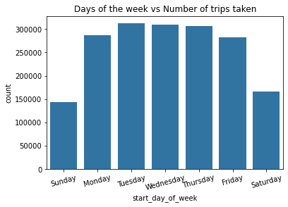

```python
# looking at the start_day_of_week column
# change column to categorical dtype

days_ = ['Sunday', 'Monday', 'Tuesday','Wednesday','Thursday','Friday','Saturday']
day_cat = pd.api.types.CategoricalDtype(categories = days_ , ordered = True)

bike['start_day_of_week']  = bike['start_day_of_week'].astype(day_cat)

week_counts = bike['start_day_of_week'].value_counts()
sum_week = week_counts.sum()
# plot
color = sb.color_palette()[0]
sb.countplot(x= bike.start_day_of_week , color = color)
plt.title('Days of the week vs Number of trips taken')

plt.xticks(rotation = 15)
plt.show()
```

> Seems most trips were taken on Tuesdays and the least amount of trips were taken on Saturdays and Sundays

```python
bike['start_day_of_week'].value_counts()
```

```
Tuesday      312209
Wednesday    309181
Thursday     306602
Monday       287143
Friday       282327
Saturday     166079
Sunday       143968
Name: start_day_of_week, dtype: int64
```

### What times of the day were most trips taken?

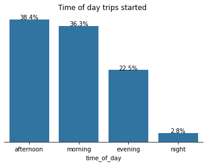

```python
order_counts  = bike['time_of_day'].value_counts()
sum_counts = order_counts.sum()
order = order_counts.index

sb.countplot(x = bike.time_of_day, color = color , order = order)
plt.title('Time of day trips started ')
perc(order_counts, sum_counts);
```

> Seems most trips were taken in the afternoon and morning , and the least amount of trips were taken in the night.

### What month of the year was most trips taken?

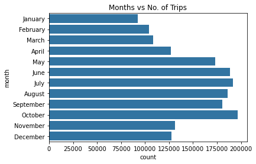

```python
sb.countplot(data = bike , y = 'month', color = color)
plt.title('Months vs No. of Trips');
```

> Most trips were taken on the month of October.

### What gender took the most trips?

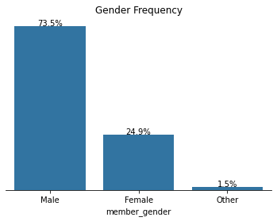

```python
counts_gen = bike['member_gender'].value_counts()
sum_gen  = counts_gen.sum()
order_ = counts_gen.index
sb.countplot(x = bike['member_gender'] , color = color, order = order_)
plt.title('Gender Frequency');
perc(counts_gen, sum_gen)
```

> Most trips were done by males.

### What age groups are most associated with the trips?

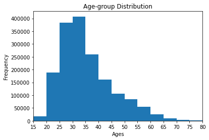

```python
# plot histogram
bins = np.arange(15,150 +5, 5)
bike['age'].plot(kind = 'hist', bins =bins)
plt.xticks(bins)
plt.xlim(15 , 80)
plt.xlabel('Ages')
plt.title('Age-group Distribution');
```

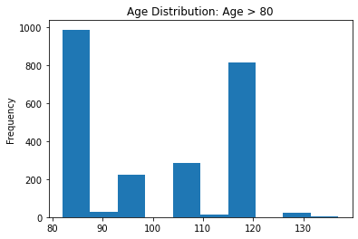

```python
bike.query("age > 80")['age'].plot(kind='hist')
plt.title('Age Distribution: Age > 80');
```

> The plot is skewed to the right. Age groups of 30-35 had the most trips